# tp 3

jules

2022-11-20

## 9) Graphiques

### Exercice 1

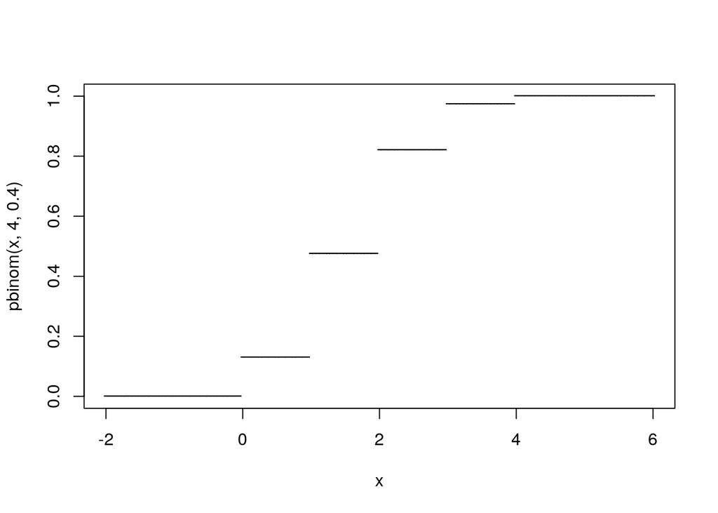

```r
x <- seq(-2,6,by=0.05)
plot(x,pbinom(x,4,.4),pch='-')
```

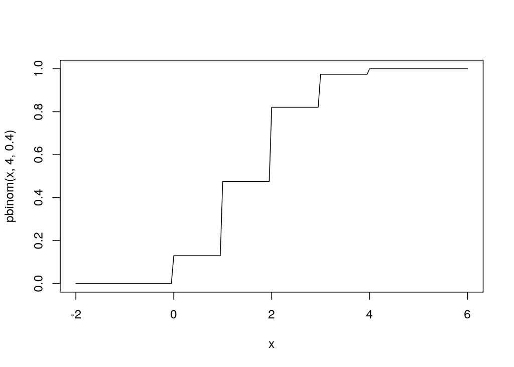

```r
x <- seq(-2,6,by=0.05)
plot(x,pbinom(x,4,.4),type='l')
```

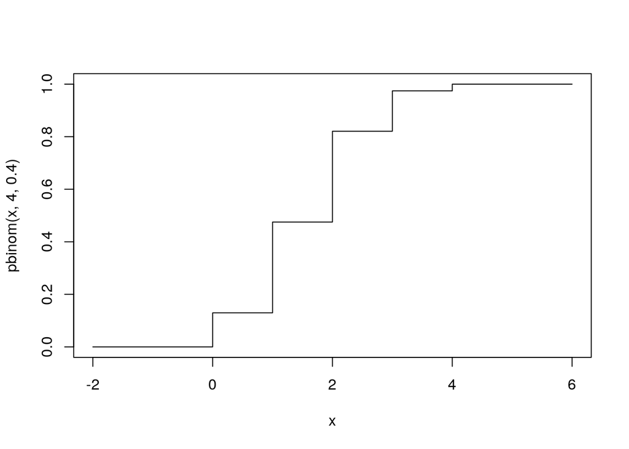

```r
x <- -2:6
plot(x,pbinom(x,4,.4),type='s')
```

Les plots (1) et (2) diffèrent par la méthode d'affichage des points : un tiret est affiché pour chaque point en (1) alors qu'une ligne continue passant par tout les points est dessinée pour (2) La commande (3) est plus optimisée que les deux première car elle n'évalue la fonction `pbinom` que pour les entiers compris entre -2 et 6, or la loi binomiale prend ses valeurs dans les entiers naturels donc les valeurs de sa fonction de répartition ne change qu'aux entiers naturels.

### Exercice 2

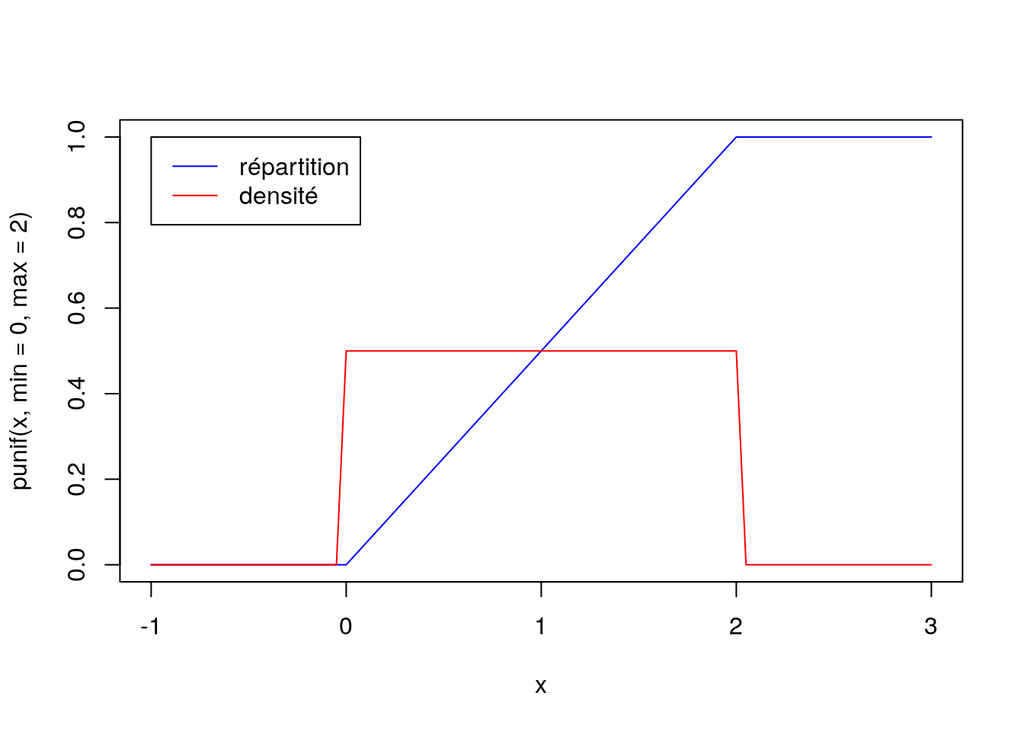

```r
x <- seq(-1,3,by=0.05)
plot(x,punif(x,min = 0,max = 2),col= 'blue',type = 'l')
lines(x,dunif(x,min = 0,max = 2),col='red',type = 'l')
legend(-1,1,legend=c("répartition","densité"), col=c("blue","red"),lty=c(1,1))
```

### Exercice 3

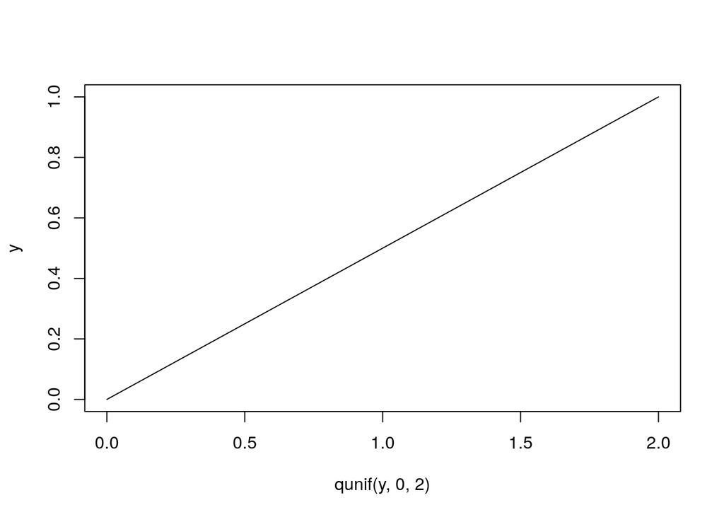

```r
y<-seq(0,1,by=0.01)
plot(qunif(y,0,2),y,type='l')
```

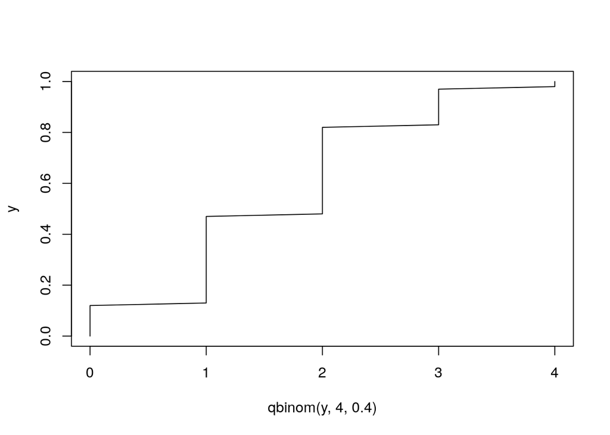

```r
y<-seq(0,1,by=0.01)
plot(qbinom(y,4,.4),y,type='l')
```

## 10) Graphiques

### Exercice 4

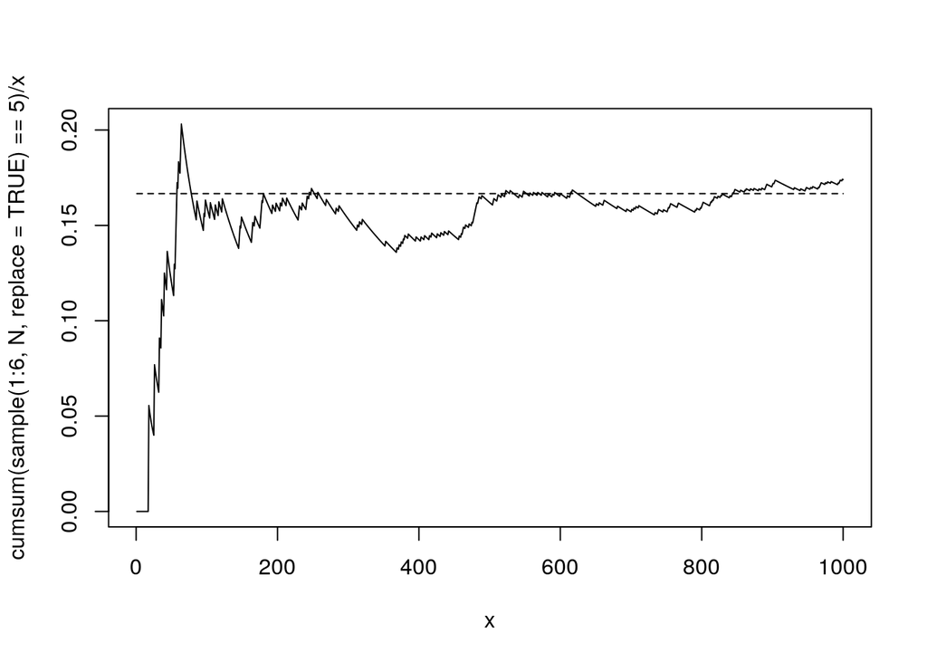

```r
N = 1000
x <- 1:N
plot(x, cumsum(sample(1:6,N,replace=TRUE)==5)/x,type="l")
lines(x,rep(1/6,N),type="l",lty=2)
```

On observe que la fréquence de 5 converge vers la probabilité d'obtenir un 5. C'est la loi des grands nombres.

### Exercice 5

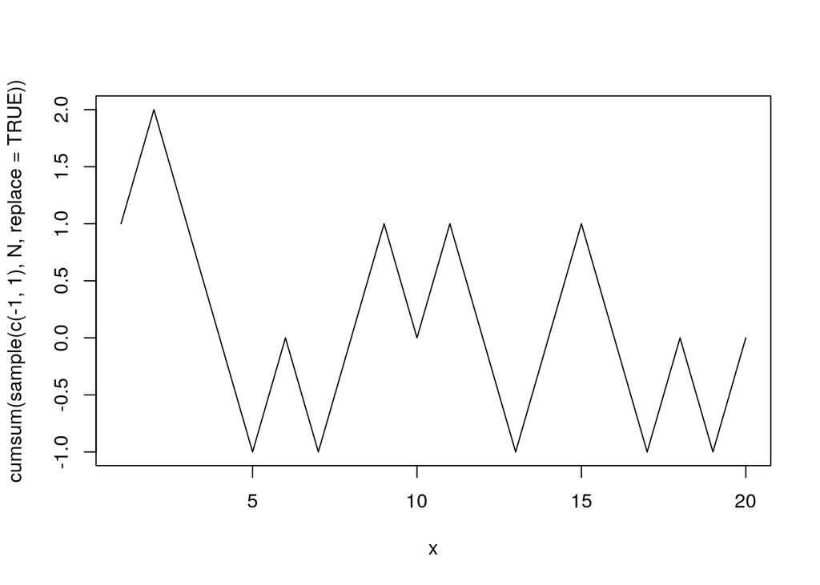

```r
N = 20
x <- 1:N
plot(x, cumsum(sample(c(-1,1),N,replace=TRUE)),type="l")
```

### Exercice 6

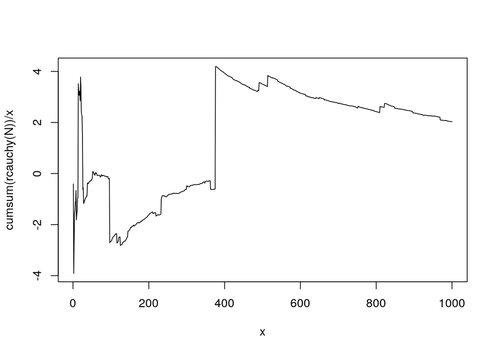

```r
N = 1000
x <- 1:N
plot(x, cumsum(rcauchy(N))/x,type="l")
```

Regardons maintenant les moyennes empiriques trouvées sur de nombreuses séries indépendantes.

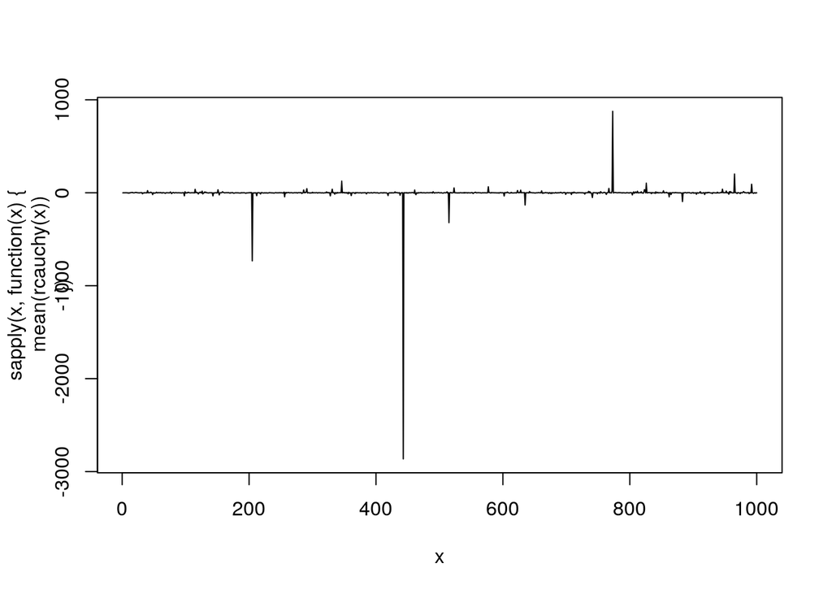

```r
N = 1000
x <- 1:N
plot(x, sapply(x, function(x){mean(rcauchy(x))}),type="l")
```

L'estimateur moyenne empririque ne semble pas converger pour n croissant. Cela s'explique par le fait que la fonction de densité de la la loi de cauchy n'est pas intégrable. La loi de cauchy n'admet donc pas d'espérance.